# #TidyTuesday Submission

Data Science for Biologists, Spring 2020

Nicholas Paterna

April 19, 2020

### TidyTuesday Week 16

Hi, I am once again attempting to make a figure for #TidyTuesday! I am a student at Rowan University in Biochemistry with *a smidge* of experience in coding thanks to [Dr. Stephanie Spielman](https://twitter.com/stephspiel). R is my first language and I am very happy to be learning it, I hope to work in Bioinformatics one day possibly Medical Genomics. I am open to criticism or helpful tips in trimming my code!!

```r
tidy_path <- "/Users/nickpaterna/datascience/TidyTuesday/Week_16/"
#This variable will tell the figure where to save when I apply ggsave!

figure_name <- "tidytues_week16.png"
#Rather than re-typing this into ggsave I can just use this!

rap_fills <- c("darkblue", "coral2")
#Assigning pretty fills for my figure.

big_6 <- c("The Notorious B.I.G.", "Public Enemy", "Mobb Deep", "Queen Latifah", "Lauryn Hill", "Missy Eilliott")
# The Notorious BIG, Public Enemy, Mobb Deep top 3 MALES
# Queen Latifah, Lauryn Hill, Missy Elliott top 3 FEMALES
```

## Avoid Hard-coding!

One of the most important things that my professor stresses is a complete aversion to HARD-CODING, or explicitly re-typing code in a large script. It might not make a lot of sense to apply these practices on a small assignment but the more often I apply it the easier to apply it is in the future! (Also the second visible code chunk gives my submission some more flavor!)

```r
rankings %>%
  select(artist, gender, points) %>%
  filter(gender != "mixed") -> filtered_ranks

head(filtered_ranks)
```

```
## # A tibble: 6 x 3
##   artist                               gender points
##   <chr>                                <chr>   <dbl>
## 1 The Notorious B.I.G.                 male      140
## 2 Public Enemy                         male      100
## 3 Mobb Deep                            male       94
## 4 Grandmaster Flash & The Furious Five male       90
## 5 Dr Dre ft. Snoop Doggy Dogg          male       84
## 6 Wu-Tang Clan                         male       62
```

## Data Wrangling

A big part of my Data Science class is utilizing the many packages in our Tidyverse Tool belt to clean up data. Here, this means filtering out unwanted values and narrowing down the observations of interest for the figure I produced after. I mostly used `dplyr` to help this process but it is still important nonetheless.

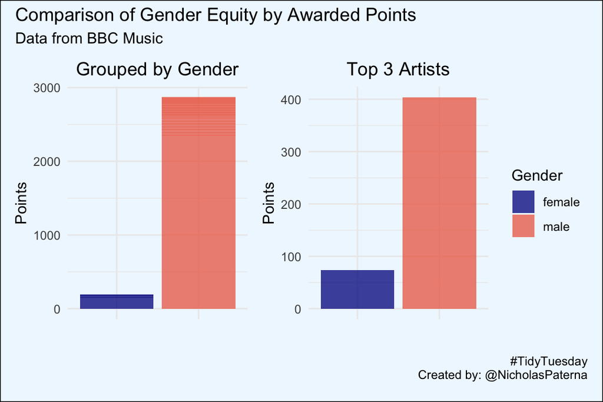

```r
filtered_ranks %>%
  select(- artist) %>%
  group_by(gender) %>%
  ggplot(aes(x = gender, y = points, fill = gender)) +
  geom_col(alpha = 0.75) +
  scale_fill_manual(values = rap_fills) +
  theme(axis.text.x = element_blank(),
        plot.title = element_text(hjust = 0.5)) +
  labs(x = "", y = "Points", fill = "Gender",
       title = "Grouped by Gender") -> all_artists

filtered_ranks %>%
  filter(artist %in% big_6) %>%
  ggplot(aes(x = gender, y = points, fill = gender)) +
  geom_col(alpha = 0.75) +
  scale_fill_manual(values = rap_fills) +
  theme(axis.text.x = element_blank(),
        plot.title = element_text(hjust = 0.5)) +
  labs(x = "", y = "Points", fill = "Gender",
       title = "Top 3 Artists") -> top_artists

all_artists + top_artists +
  plot_layout(guides = "collect") +
  plot_annotation(title = "Comparison of Gender Equity by Awarded Points",
                  subtitle = "Data from BBC Music",
                  caption = "#TidyTuesday\n Created by: @NicholasPaterna\n",
                  theme = theme(plot.background =
                                  element_rect(fill = "aliceblue"))) -> rap_plot


ggsave(paste0(tidy_path, figure_name), rap_plot, width = 6, height = 4)
rap_plot
```

I had SO much fun doing this week’s #TidyTuesday! I love music and interacting with data tied to hip-hop was exciting as it is one of my favorite genres. Using this dataset I examined the lack of representation for female artists by their garnered point value from these critics. Personally, I prefer listening to female rap and Missy Elliot is one of my favorite artists of all time (“Beep Me 911” is a classic). I also altered aspects of the theme with `plot_annotation()`, and realized that the `patchwork` package is much easier to use than I realized!

I hope you enjoy my plot, you can find this and future entries on my [GitHub](https://github.com/npaterna/datascience/tree/master/TidyTuesday).